# PW3 - Multiple Linear Regression

Sandrine NEANG - SB2

05/10/2022 & 08/10/2022

**Question 1 : load the Boston dataset from MASS package**

```r
library(MASS)
data("Boston")
```

**Question 2 : split the dataset Boston into training set and testing test**

```r
variables = c("crim", "zn", "indus", "chas", "nox", "rm","age", "dis","rad", "tax","ptratio", "black","lstat", "medv")
train = 1:400
test = -train
training_data = Boston[train, variables]
testing_data = Boston[test, variables]
```

**Question 3 : is there a linear relationship between the variables “medv” and “age” ?**

```r
cor(training_data$medv, training_data$age)
```

```
## [1] -0.278153
```

The correlation value is not equals to zero, there is a linear relationship.

**Question 4 : fit a model of housing prices in function of age and plot the observations and the regression line**

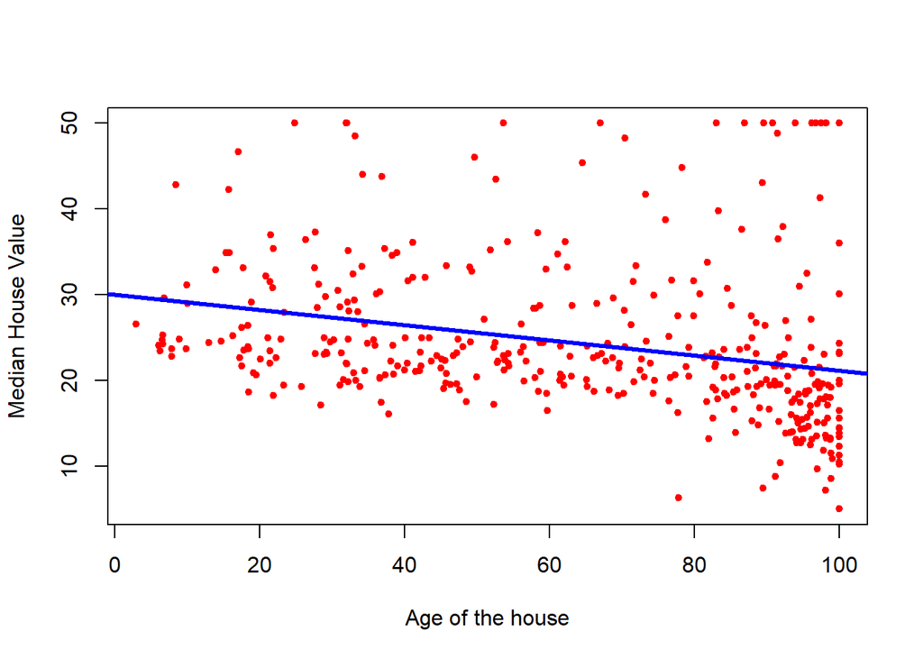

```r
model1 = lm(medv~age, data = training_data)
plot(training_data$age, training_data$medv,
     xlab="Age of the house",
     ylab="Median House Value",
     col="red",
     pch=20)

abline(model1,col="blue",lwd=3)
```

**Question 5 : train a regression model using both lstat and age as predictors of median house value**

```r
model2 = lm(medv ~log(lstat) + age, data=training_data)
model2
```

```
##
## Call:
## lm(formula = medv ~ log(lstat) + age, data = training_data)
##
## Coefficients:
## (Intercept)   log(lstat)          age
##    51.60212    -14.33897      0.07779
```

```r
library(rgl)
```

```r
options(rgl.printRglwidget = TRUE)

rgl::plot3d(log(Boston$lstat),
            Boston$age,
            Boston$medv, type = "p",
            xlab = "log(lstat)",
            ylab = "age",
            zlab = "medv", site = 5, lwd = 15)


rgl::planes3d(model2$coefficients["log(lstat)"],
              model2$coefficients["age"], -1,
              model2$coefficients["(Intercept)"], alpha = 0.3, front = "line")
```

[interactive chart not shown]

**Question 6 : print the summary of the obtained regression model**

```
##
## Call:
## lm(formula = medv ~ log(lstat) + age, data = training_data)
##
## Residuals:
##      Min       1Q   Median       3Q      Max
## -13.5262  -3.3942  -0.8392   2.7503  22.9450
##
## Coefficients:
##              Estimate Std. Error t value Pr(>|t|)
## (Intercept)  51.60212    1.03643  49.788  < 2e-16 ***
## log(lstat)  -14.33897    0.53904 -26.601  < 2e-16 ***
## age           0.07779    0.01106   7.034 8.85e-12 ***
## ---
## Signif. codes:  0 '***' 0.001 '**' 0.01 '*' 0.05 '.' 0.1 ' ' 1
##
## Residual standard error: 5.292 on 397 degrees of freedom
## Multiple R-squared:  0.6684, Adjusted R-squared:  0.6667
## F-statistic: 400.1 on 2 and 397 DF,  p-value: < 2.2e-16
```

**Question 8 : is the model as a whole is significant ?**

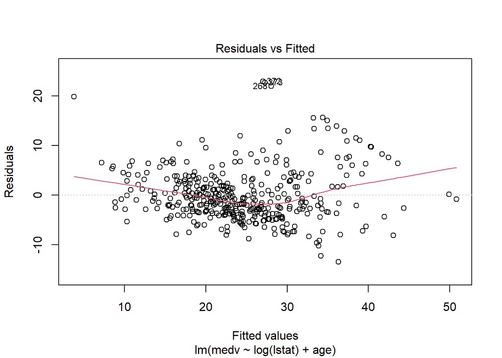

Here, linearity is violated because the red line isn’t strictly horizontal.

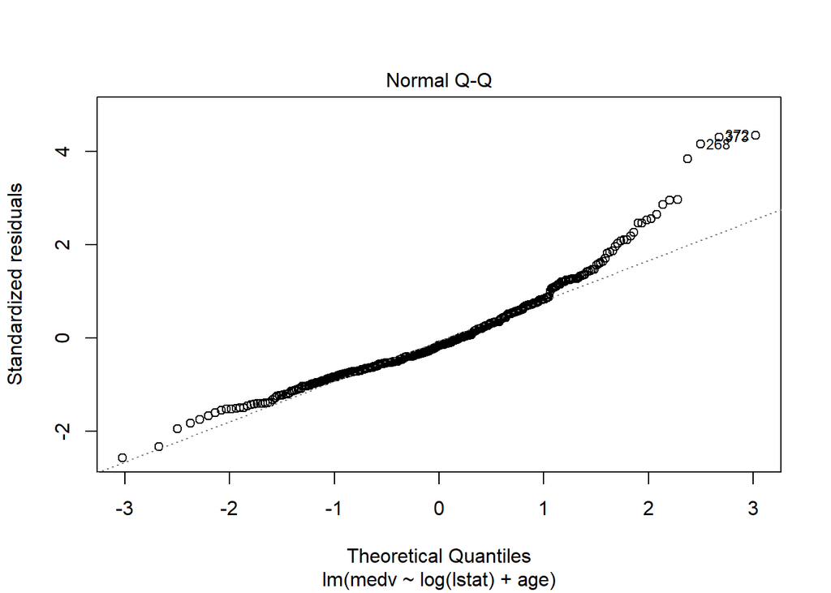

Values with theoretical quantiles > 1 are not following the line.

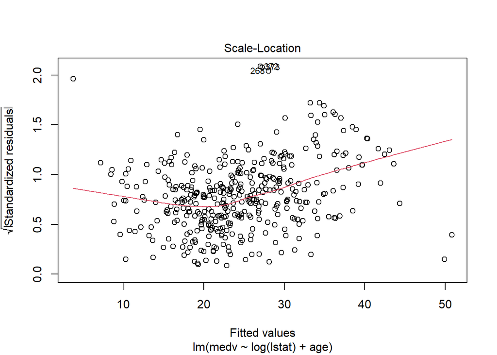

The points are not equally spread in the plot which means that our model is a heteroscedacity model.

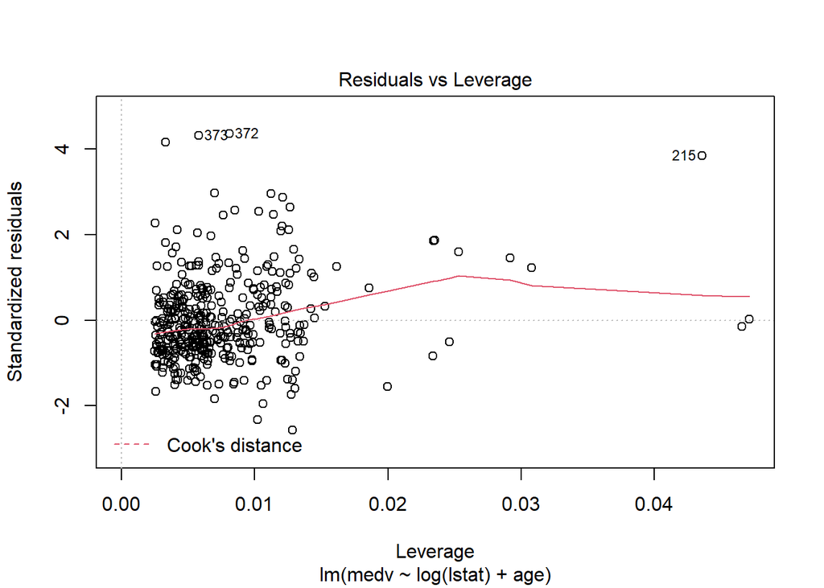

**Question 9 : train a new model using all the variables of the dataset**

```r
model3 = lm(medv ~ ., data=training_data)
model3
```

```
##
## Call:
## lm(formula = medv ~ ., data = training_data)
##
## Coefficients:
## (Intercept)         crim           zn        indus         chas          nox
##   28.672600    -0.191246     0.044229     0.055221     1.716314   -14.995722
##          rm          age          dis          rad          tax      ptratio
##    4.887730     0.002609    -1.294808     0.484787    -0.015401    -0.808795
##       black        lstat
##   -0.001292    -0.517954
```

**Question 10 : re train the model using log(lstat) instead of lstat**

```r
model4 = lm(medv ~ . + log(lstat) - lstat, data=training_data)
model4
```

```
##
## Call:
## lm(formula = medv ~ . + log(lstat) - lstat, data = training_data)
##
## Coefficients:
## (Intercept)         crim           zn        indus         chas          nox
##   48.806352    -0.178036     0.026440     0.033649     1.546766   -14.007310
##          rm          age          dis          rad          tax      ptratio
##    3.321905     0.030437    -1.109645     0.418017    -0.014570    -0.736532
##       black   log(lstat)
##   -0.001398    -8.795266
```

**Question 11 : did R² improve ? Yes**  
model3 : Multiple R-squared: 0.7339, Adjusted R-squared: 0.7249  
model4 : Multiple R-squared: 0.785, Adjusted R-squared: 0.7777

**Question 12 : to see if there is correlated variables, print the correlation matrix using the cor() function**

```r
round(cor(training_data),2)
```

```
##          crim    zn indus  chas   nox    rm   age   dis   rad   tax ptratio
## crim     1.00 -0.16  0.35  0.01  0.38 -0.17  0.29 -0.32  0.63  0.58    0.20
## zn      -0.16  1.00 -0.50 -0.08 -0.49  0.31 -0.55  0.64 -0.24 -0.22   -0.33
## indus    0.35 -0.50  1.00  0.16  0.75 -0.40  0.61 -0.67  0.46  0.59    0.24
## chas     0.01 -0.08  0.16  1.00  0.17  0.08  0.14 -0.17  0.13  0.09   -0.07
## nox      0.38 -0.49  0.75  0.17  1.00 -0.31  0.71 -0.75  0.53  0.61    0.03
## rm      -0.17  0.31 -0.40  0.08 -0.31  1.00 -0.23  0.17 -0.22 -0.31   -0.36
## age      0.29 -0.55  0.61  0.14  0.71 -0.23  1.00 -0.73  0.39  0.44    0.16
## dis     -0.32  0.64 -0.67 -0.17 -0.75  0.17 -0.73  1.00 -0.42 -0.45   -0.10
## rad      0.63 -0.24  0.46  0.13  0.53 -0.22  0.39 -0.42  1.00  0.87    0.33
## tax      0.58 -0.22  0.59  0.09  0.61 -0.31  0.44 -0.45  0.87  1.00    0.30
## ptratio  0.20 -0.33  0.24 -0.07  0.03 -0.36  0.16 -0.10  0.33  0.30    1.00
## black   -0.05  0.13 -0.28 -0.05 -0.35  0.20 -0.21  0.21 -0.06 -0.16    0.08
## lstat    0.38 -0.39  0.55  0.00  0.53 -0.65  0.57 -0.42  0.36  0.42    0.29
## medv    -0.27  0.31 -0.37  0.14 -0.30  0.75 -0.28  0.11 -0.19 -0.31   -0.44
##         black lstat  medv
## crim    -0.05  0.38 -0.27
## zn       0.13 -0.39  0.31
## indus   -0.28  0.55 -0.37
## chas    -0.05  0.00  0.14
## nox     -0.35  0.53 -0.30
## rm       0.20 -0.65  0.75
## age     -0.21  0.57 -0.28
## dis      0.21 -0.42  0.11
## rad     -0.06  0.36 -0.19
## tax     -0.16  0.42 -0.31
## ptratio  0.08  0.29 -0.44
## black    1.00 -0.17  0.15
## lstat   -0.17  1.00 -0.70
## medv     0.15 -0.70  1.00
```

**Question 13 : visualize the correlations using the corrplot package, then use the function corrplot.mixed()**

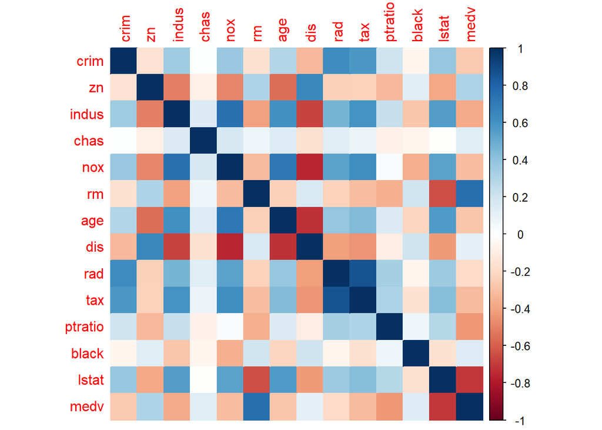

```r
library(corrplot)
M = cor(training_data)
corrplot(M, method = 'color')
```

**Question 14 : what is the correlation between tax and rad?**

```r
cor(training_data$tax,training_data$rad)
```

```
## [1] 0.8681268
```

**Question 15 : run the model again without tax, what happens to the R² and for the F-statistic ?**

```r
model5 = lm(medv ~ . + log(lstat) - lstat - tax, data=training_data)
summary(model5)
```

```
##
## Call:
## lm(formula = medv ~ . + log(lstat) - lstat - tax, data = training_data)
##
## Residuals:
##      Min       1Q   Median       3Q      Max
## -18.8470  -2.5354  -0.2791   1.9508  23.3798
##
## Coefficients:
##               Estimate Std. Error t value Pr(>|t|)
## (Intercept)  4.624e+01  5.944e+00   7.779 6.70e-14 ***
## crim        -1.844e-01  4.877e-02  -3.782 0.000180 ***
## zn           1.692e-02  1.261e-02   1.341 0.180600
## indus       -3.080e-02  5.686e-02  -0.542 0.588310
## chas         1.845e+00  8.096e-01   2.279 0.023184 *
## nox         -1.598e+01  4.123e+00  -3.876 0.000125 ***
## rm           3.431e+00  4.681e-01   7.329 1.36e-12 ***
## age          2.882e-02  1.334e-02   2.160 0.031412 *
## dis         -1.146e+00  1.939e-01  -5.909 7.54e-09 ***
## rad          2.063e-01  5.403e-02   3.817 0.000157 ***
## ptratio     -7.658e-01  1.279e-01  -5.989 4.82e-09 ***
## black        3.066e-04  5.940e-03   0.052 0.958855
## log(lstat)  -8.753e+00  6.558e-01 -13.347  < 2e-16 ***
## ---
## Signif. codes:  0 '***' 0.001 '**' 0.01 '*' 0.05 '.' 0.1 ' ' 1
##
## Residual standard error: 4.39 on 387 degrees of freedom
## Multiple R-squared:  0.7775, Adjusted R-squared:  0.7706
## F-statistic: 112.7 on 12 and 387 DF,  p-value: < 2.2e-16
```

**model4 :**  
Residual standard error: 4.321 on 386 degrees of freedom  
Multiple R-squared: 0.785, Adjusted R-squared: 0.7777  
F-statistic: 108.4 on 13 and 386 DF, p-value: < 2.2e-16

**model5 :**  
Residual standard error: 4.39 on 387 degrees of freedom  
Multiple R-squared: 0.7775, Adjusted R-squared: 0.7706  
F-statistic: 112.7 on 12 and 387 DF, p-value: < 2.2e-16

**Question 16 : calculate the mean squared error (MSE) for the last model**

```r
RSE=4.39
R2=0.7775
Fstatistic=112.7

error = RSE/mean(training_data$medv)
error
```

```
## [1] 0.1804023
```

**Question 17 : Use command str() to see how the variable chas is present in the dataset. How many of the suburbs in this dataset bound the Charles river ?**

```r
str(training_data$chas)
```

```
##  int [1:400] 0 0 0 0 0 0 0 0 0 0 ...
```

**Question 18 : Create boxplots of the median value of houses with respect to the variable chas. Do we observe some difference between the median value of houses with respect to the neighborhood to Charles River ?**

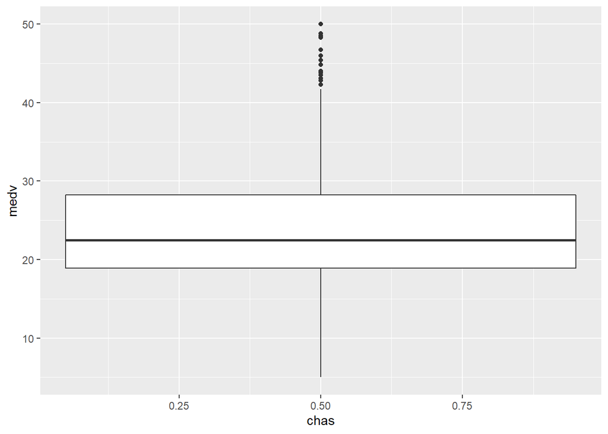

```r
library(ggplot2)
p = ggplot(training_data, aes(x=chas,y=medv))+geom_boxplot()
p
```

**Question 19 : Calculate μi and μj (using the function aggregate())**

```r
aggregate(training_data[,c("chas","medv")], list(training_data$chas),mean)
```

```
##   Group.1 chas     medv
## 1       0    0 23.94082
## 2       1    1 28.44000
```

**Question 20 : Apply an ANOVA test of medv which respect to chas. Print the result and the summary of it. What do you conclude ?**

```r
fit <- aov(medv ~ chas, data=training_data)
summary(fit)
```

```
##              Df Sum Sq Mean Sq F value Pr(>F)
## chas          1    646   646.5   7.826 0.0054 **
## Residuals   398  32876    82.6
## ---
## Signif. codes:  0 '***' 0.001 '**' 0.01 '*' 0.05 '.' 0.1 ' ' 1
```

**Question 21 : Fit a new model where the predictors are the Charles River and the Crime Rate. Interpret the coefficients of this model and conclude if the presence of the river adds a valuable information for explaining the house price.**

```r
model6 <- lm(medv ~ chas + crim, data = training_data)
summary(model6)
```

```
##
## Call:
## lm(formula = medv ~ chas + crim, data = training_data)
##
## Residuals:
##     Min      1Q  Median      3Q     Max
## -14.441  -5.823  -2.127   3.779  29.113
##
## Coefficients:
##             Estimate Std. Error t value Pr(>|t|)
## (Intercept) 24.65057    0.47619  51.766  < 2e-16 ***
## chas         4.54421    1.55098   2.930  0.00359 **
## crim        -0.40762    0.07328  -5.562  4.9e-08 ***
## ---
## Signif. codes:  0 '***' 0.001 '**' 0.01 '*' 0.05 '.' 0.1 ' ' 1
##
## Residual standard error: 8.765 on 397 degrees of freedom
## Multiple R-squared:  0.09019,    Adjusted R-squared:  0.0856
## F-statistic: 19.68 on 2 and 397 DF,  p-value: 7.11e-09
```

**Question 22 : Is chas is significant as well in the presence of more predictors ?**

```r
model5 = lm(medv ~ . + log(lstat) - lstat - tax, data=training_data)
summary(model5)
```

```
##
## Call:
## lm(formula = medv ~ . + log(lstat) - lstat - tax, data = training_data)
##
## Residuals:
##      Min       1Q   Median       3Q      Max
## -18.8470  -2.5354  -0.2791   1.9508  23.3798
##
## Coefficients:
##               Estimate Std. Error t value Pr(>|t|)
## (Intercept)  4.624e+01  5.944e+00   7.779 6.70e-14 ***
## crim        -1.844e-01  4.877e-02  -3.782 0.000180 ***
## zn           1.692e-02  1.261e-02   1.341 0.180600
## indus       -3.080e-02  5.686e-02  -0.542 0.588310
## chas         1.845e+00  8.096e-01   2.279 0.023184 *
## nox         -1.598e+01  4.123e+00  -3.876 0.000125 ***
## rm           3.431e+00  4.681e-01   7.329 1.36e-12 ***
## age          2.882e-02  1.334e-02   2.160 0.031412 *
## dis         -1.146e+00  1.939e-01  -5.909 7.54e-09 ***
## rad          2.063e-01  5.403e-02   3.817 0.000157 ***
## ptratio     -7.658e-01  1.279e-01  -5.989 4.82e-09 ***
## black        3.066e-04  5.940e-03   0.052 0.958855
## log(lstat)  -8.753e+00  6.558e-01 -13.347  < 2e-16 ***
## ---
## Signif. codes:  0 '***' 0.001 '**' 0.01 '*' 0.05 '.' 0.1 ' ' 1
##
## Residual standard error: 4.39 on 387 degrees of freedom
## Multiple R-squared:  0.7775, Adjusted R-squared:  0.7706
## F-statistic: 112.7 on 12 and 387 DF,  p-value: < 2.2e-16
```

**Question 23 : Fit a model with first order interaction term where predictors are lstat and age. Print its summary.**

```r
model7 <- lm( medv ~ log(lstat) + age + log(lstat)*age, data = training_data)
summary(model7)
```

```
##
## Call:
## lm(formula = medv ~ log(lstat) + age + log(lstat) * age, data = training_data)
##
## Residuals:
##      Min       1Q   Median       3Q      Max
## -13.9868  -3.4353  -0.8888   2.5845  22.8389
##
## Coefficients:
##                 Estimate Std. Error t value Pr(>|t|)
## (Intercept)     46.33303    2.61349  17.728  < 2e-16 ***
## log(lstat)     -11.64746    1.33881  -8.700  < 2e-16 ***
## age              0.15301    0.03600   4.250 2.67e-05 ***
## log(lstat):age  -0.03644    0.01661  -2.194   0.0288 *
## ---
## Signif. codes:  0 '***' 0.001 '**' 0.01 '*' 0.05 '.' 0.1 ' ' 1
##
## Residual standard error: 5.266 on 396 degrees of freedom
## Multiple R-squared:  0.6724, Adjusted R-squared:  0.6699
## F-statistic: 270.9 on 3 and 396 DF,  p-value: < 2.2e-16
```

**Question 24 : Fit a model with all the first order interactions terms.**

```r
model8 <- lm( medv ~ .^2, data = training_data)
summary(model8)
```

```
##
## Call:
## lm(formula = medv ~ .^2, data = training_data)
##
## Residuals:
##     Min      1Q  Median      3Q     Max
## -6.6615 -1.3732 -0.0501  1.2695 11.7695
##
## Coefficients:
##                 Estimate Std. Error t value Pr(>|t|)
## (Intercept)   -2.998e+02  9.415e+01  -3.184 0.001600 **
## crim          -4.827e+00  6.651e+00  -0.726 0.468531
## zn            -5.831e-03  5.056e-01  -0.012 0.990807
## indus          1.474e+00  1.812e+00   0.814 0.416476
## chas           1.890e+01  1.898e+01   0.995 0.320279
## nox            1.639e+02  8.333e+01   1.967 0.050123 .
## rm             4.398e+01  8.045e+00   5.467 9.48e-08 ***
## age            4.100e-01  3.219e-01   1.274 0.203795
## dis           -1.393e+00  6.137e+00  -0.227 0.820619
## rad            5.092e+00  2.708e+00   1.880 0.060991 .
## tax           -2.056e-01  1.632e-01  -1.260 0.208754
## ptratio        6.903e+00  2.913e+00   2.370 0.018396 *
## black          3.817e-01  1.737e-01   2.198 0.028726 *
## lstat          3.738e-02  1.071e+00   0.035 0.972177
## crim:zn        2.308e-01  1.660e-01   1.390 0.165558
## crim:indus    -1.173e-02  4.277e-01  -0.027 0.978138
## crim:chas      2.951e+00  5.467e-01   5.397 1.36e-07 ***
## crim:nox      -9.358e+00  3.778e+00  -2.477 0.013781 *
## crim:rm        5.883e-02  1.256e-01   0.468 0.639952
## crim:age      -1.197e-02  1.008e-02  -1.187 0.236031
## crim:dis      -5.628e-01  3.207e-01  -1.755 0.080209 .
## crim:rad      -3.706e-01  5.560e-01  -0.667 0.505520
## crim:tax       2.096e-02  4.087e-02   0.513 0.608435
## crim:ptratio   4.215e-01  3.173e-01   1.329 0.184992
## crim:black    -3.644e-03  3.078e-03  -1.184 0.237404
## crim:lstat     3.364e-02  1.419e-02   2.370 0.018397 *
## zn:indus      -2.679e-03  4.309e-03  -0.622 0.534650
## zn:chas       -1.268e-01  5.857e-02  -2.166 0.031105 *
## zn:nox        -1.089e-01  4.577e-01  -0.238 0.812060
## zn:rm         -6.488e-03  2.445e-02  -0.265 0.790913
```

[output cut: 53 more lines]

```
## rad:ptratio   -9.354e-02  9.247e-02  -1.012 0.312502
## rad:black     -4.195e-03  3.819e-03  -1.099 0.272803
## rad:lstat     -5.496e-02  2.016e-02  -2.726 0.006772 **
## tax:ptratio    5.187e-03  2.487e-03   2.086 0.037825 *
## tax:black      3.310e-04  2.668e-04   1.241 0.215612
## tax:lstat     -7.153e-04  1.303e-03  -0.549 0.583417
## ptratio:black -7.348e-03  3.661e-03  -2.007 0.045591 *
## ptratio:lstat  1.568e-02  3.075e-02   0.510 0.610566
## black:lstat    3.132e-03  1.138e-03   2.751 0.006291 **
## ---
## Signif. codes:  0 '***' 0.001 '**' 0.01 '*' 0.05 '.' 0.1 ' ' 1
##
## Residual standard error: 2.513 on 308 degrees of freedom
## Multiple R-squared:  0.942,  Adjusted R-squared:  0.9249
## F-statistic: 54.96 on 91 and 308 DF,  p-value: < 2.2e-16
```